# Prediction Assignment Writeup

Julia Maier

2025-12-08

### Background

Using devices such as Jawbone Up, Nike FuelBand, and Fitbit it is now possible to collect a large amount of data about personal activity relatively inexpensively. These type of devices are part of the quantified self movement – a group of enthusiasts who take measurements about themselves regularly to improve their health, to find patterns in their behavior, or because they are tech geeks. One thing that people regularly do is quantify how much of a particular activity they do, but they rarely quantify how well they do it. In this project, our goal will be to use data from accelerometers on the belt, forearm, arm, and dumbell of 6 participants. They were asked to perform barbell lifts correctly and incorrectly in 5 different ways. More information is available from the website here: http://web.archive.org/web/20161224072740/http:/groupware.les.inf.puc-rio.br/har (see the section on the Weight Lifting Exercise Dataset).

**Reference**:

Velloso, E.; Bulling, A.; Gellersen, H.; Ugulino, W.; Fuks, H. Qualitative Activity Recognition of Weight Lifting Exercises. Proceedings of 4th International Conference in Cooperation with SIGCHI (Augmented Human ’13) . Stuttgart, Germany: ACM SIGCHI, 2013.

### Goal of this project

The goal of this project is to predict the manner in which participants did the predefined exercise. This is the “classe” variable in the training set. You may use any of the other variables to predict with. You should create a report describing how you built your model, how you used cross validation, what you think the expected out of sample error is, and why you made the choices you did. You will also use your prediction model to predict 20 different test cases.

### Preparation of dataset

In a first step, data are loaded from the website. They are then processed to create clean datasets.

```r
# Create datasets

## Download and save datasets

url_train <- "https://d396qusza40orc.cloudfront.net/predmachlearn/pml-training.csv"
url_test  <- "https://d396qusza40orc.cloudfront.net/predmachlearn/pml-testing.csv"

if(!file.exists("pml-training.csv"))  {
  download.file(url_train, "pml-training.csv", method = "curl")
}

if(!file.exists("pml-testing.csv"))  {
  download.file(url_test, "pml-testing.csv", method = "curl")
}


## Load TRAINING DATA

# 1) Read training data
raw <- readLines("pml-training.csv", warn = FALSE)

# 2) Remove Backslash-escaped quotes (\"), and all " Signs
    raw <- gsub('\\\\\"', '', raw, perl = TRUE)
    clean <- gsub('"', '', raw, fixed = TRUE)

# 3) Save clean data set
    writeLines(clean, "pml-training_noquotes.csv", useBytes = TRUE)

    data_train <- read.csv("pml-training_noquotes.csv", na.strings = c("NA", "#DIV/0!", ""), stringsAsFactors = FALSE)


## Load TEST DATA

# 1) Read testing data
raw <- readLines("pml-testing.csv", warn = FALSE)

# 2) Remove Backslash-escaped quotes (\"), and all " Signs
    raw <- gsub('\\\\\"', '', raw, perl = TRUE)
    clean <- gsub('"', '', raw, fixed = TRUE)

# 3) Save clean data set
    writeLines(clean, "pml-testing_noquotes.csv", useBytes = TRUE)

    data_test <- read.csv("pml-testing_noquotes.csv", na.strings = c("NA", "#DIV/0!", ""), stringsAsFactors = FALSE)

dim(data_train)
```

```
## [1] 19622   160
```

```r
dim(data_test)
```

```
## [1]  20 160
```

```r
 ## Remove NA > 95%

  na_thresh <- 0.95
  valid_cols <- colMeans(is.na(data_train)) < na_thresh
  data_train <- data_train[, valid_cols]

 ## Remove irrelevant variables
  drop_cols <- c("X", "user_name", "cvtd_timestamp", "raw_timestamp_part_1", "raw_timestamp_part_2", "new_window", "num_window")

  data_train <- data_train[, !(names(data_train) %in% drop_cols)]


 ## Define Factor

  data_train$classe <- factor(data_train$classe)


 ## Data overview

  str(data_test)
```

```
## 'data.frame':    20 obs. of  160 variables:
##  $ X                       : int  1 2 3 4 5 6 7 8 9 10 ...
##  $ user_name               : chr  "pedro" "jeremy" "jeremy" "adelmo" ...
##  $ raw_timestamp_part_1    : int  1323095002 1322673067 1322673075 1322832789 1322489635 1322673149 1322673128 1322673076 1323084240 1322837822 ...
##  $ raw_timestamp_part_2    : int  868349 778725 342967 560311 814776 510661 766645 54671 916313 384285 ...
##  $ cvtd_timestamp          : chr  "05/12/2011 14:23" "30/11/2011 17:11" "30/11/2011 17:11" "02/12/2011 13:33" ...
##  $ new_window              : chr  "no" "no" "no" "no" ...
##  $ num_window              : int  74 431 439 194 235 504 485 440 323 664 ...
##  $ roll_belt               : num  123 1.02 0.87 125 1.35 -5.92 1.2 0.43 0.93 114 ...
##  $ pitch_belt              : num  27 4.87 1.82 -41.6 3.33 1.59 4.44 4.15 6.72 22.4 ...
##  $ yaw_belt                : num  -4.75 -88.9 -88.5 162 -88.6 -87.7 -87.3 -88.5 -93.7 -13.1 ...
##  $ total_accel_belt        : int  20 4 5 17 3 4 4 4 4 18 ...
##  $ kurtosis_roll_belt      : logi  NA NA NA NA NA NA ...
##  $ kurtosis_picth_belt     : logi  NA NA NA NA NA NA ...
##  $ kurtosis_yaw_belt       : logi  NA NA NA NA NA NA ...
```

[output cut: 86 more lines]

```r
  str(data_train)
```

```
## 'data.frame':    19622 obs. of  53 variables:
##  $ roll_belt           : num  1.41 1.41 1.42 1.48 1.48 1.45 1.42 1.42 1.43 1.45 ...
##  $ pitch_belt          : num  8.07 8.07 8.07 8.05 8.07 8.06 8.09 8.13 8.16 8.17 ...
##  $ yaw_belt            : num  -94.4 -94.4 -94.4 -94.4 -94.4 -94.4 -94.4 -94.4 -94.4 -94.4 ...
##  $ total_accel_belt    : int  3 3 3 3 3 3 3 3 3 3 ...
##  $ gyros_belt_x        : num  0 0.02 0 0.02 0.02 0.02 0.02 0.02 0.02 0.03 ...
##  $ gyros_belt_y        : num  0 0 0 0 0.02 0 0 0 0 0 ...
##  $ gyros_belt_z        : num  -0.02 -0.02 -0.02 -0.03 -0.02 -0.02 -0.02 -0.02 -0.02 0 ...
##  $ accel_belt_x        : int  -21 -22 -20 -22 -21 -21 -22 -22 -20 -21 ...
##  $ accel_belt_y        : int  4 4 5 3 2 4 3 4 2 4 ...
##  $ accel_belt_z        : int  22 22 23 21 24 21 21 21 24 22 ...
##  $ magnet_belt_x       : int  -3 -7 -2 -6 -6 0 -4 -2 1 -3 ...
##  $ magnet_belt_y       : int  599 608 600 604 600 603 599 603 602 609 ...
##  $ magnet_belt_z       : int  -313 -311 -305 -310 -302 -312 -311 -313 -312 -308 ...
##  $ roll_arm            : num  -128 -128 -128 -128 -128 -128 -128 -128 -128 -128 ...
```

[output cut: 39 more lines]

## Gradient Boosting Model

As a first step, a Gradient Boosting Model was built and trained.

```r
set.seed(123)

ctrl <- trainControl(method = "cv", number = 3)

gbm_cv <- train(
  classe ~ .,
  data = data_train,
  method = "gbm",
  trControl = ctrl,
  verbose = FALSE
)

gbm_cv
```

```
## Stochastic Gradient Boosting
##
## 19622 samples
##    52 predictor
##     5 classes: 'A', 'B', 'C', 'D', 'E'
##
## No pre-processing
## Resampling: Cross-Validated (3 fold)
## Summary of sample sizes: 13083, 13080, 13081
## Resampling results across tuning parameters:
##
##   interaction.depth  n.trees  Accuracy   Kappa
##   1                   50      0.7498725  0.6828383
##   1                  100      0.8195895  0.7716751
##   1                  150      0.8535822  0.8147405
##   2                   50      0.8568947  0.8187154
##   2                  100      0.9062777  0.8814089
##   2                  150      0.9336451  0.9160353
##   3                   50      0.8930277  0.8645596
##   3                  100      0.9415956  0.9260986
##   3                  150      0.9606050  0.9501609
##
## Tuning parameter 'shrinkage' was held constant at a value of 0.1
##
## Tuning parameter 'n.minobsinnode' was held constant at a value of 10
## Accuracy was used to select the optimal model using the largest value.
## The final values used for the model were n.trees = 150, interaction.depth =
##  3, shrinkage = 0.1 and n.minobsinnode = 10.
```

THe model has been cross-validated using 3 fold cross-validation. The resulting accuracy was .961 with Kappa = .950.

### Random Forest Model

In a second step, a Random Forest Model is trained. It is then tested in the test data set.

```r
set.seed(1122)

## Cross-validation

  ctrl <- trainControl(method = "cv",
                     number = 5,
                     verboseIter = TRUE,
                     allowParallel = TRUE)

  rf_cv <- train(classe ~ .,
                 data = data_train,
                 method = "rf",
                 trControl =  trainControl(method = "cv", number = 3))

  rf_cv
```

```
## Random Forest
##
## 19622 samples
##    52 predictor
##     5 classes: 'A', 'B', 'C', 'D', 'E'
##
## No pre-processing
## Resampling: Cross-Validated (3 fold)
## Summary of sample sizes: 13082, 13080, 13082
## Resampling results across tuning parameters:
##
##   mtry  Accuracy   Kappa
##    2    0.9923045  0.9902658
##   27    0.9920496  0.9899429
##   52    0.9865968  0.9830434
##
## Accuracy was used to select the optimal model using the largest value.
## The final value used for the model was mtry = 2.
```

```r
# Select variables
test_use <- data_test[, names(data_train)[names(data_train) != "classe"]]


# use test data set

rf_pred1 <- predict(gbm_cv, test_use)
rf_pred1
```

```
##  [1] B A B A A E D B A A B C B A E E A B B B
## Levels: A B C D E
```

```r
rf_pred2 <- predict(rf_cv, test_use)
rf_pred2
```

```
##  [1] B A B A A E D B A A B C B A E E A B B B
## Levels: A B C D E
```

## Comparison of models

In a last step, both models are compared as regards their prediction accuracy.

```r
results <- resamples(list(RandomForest = rf_cv, GBM = gbm_cv))
summary(results)
```

```
##
## Call:
## summary.resamples(object = results)
##
## Models: RandomForest, GBM
## Number of resamples: 3
##
## Accuracy
##                   Min.   1st Qu.    Median      Mean   3rd Qu.      Max. NA's
## RandomForest 0.9914373 0.9920489 0.9926606 0.9923045 0.9927381 0.9928157    0
## GBM          0.9576388 0.9589448 0.9602507 0.9606050 0.9620881 0.9639254    0
##
## Kappa
##                   Min.   1st Qu.    Median      Mean   3rd Qu.      Max. NA's
## RandomForest 0.9891709 0.9899429 0.9907148 0.9902658 0.9908132 0.9909117    0
## GBM          0.9464185 0.9480545 0.9496904 0.9501609 0.9520321 0.9543738    0
```

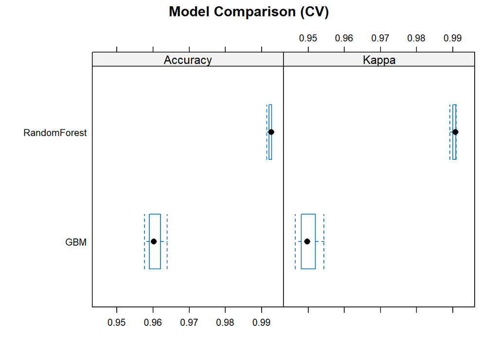

```r
bwplot(results, main = "Model Comparison (CV)")
```

Considering the direct comparison of both models, Random Forest allows for a better prediction than Gradient Boosting.